# Lab4-3_inclasslab

Nathaniel Evans

November 6, 2018

```r
stars <- c(84, 57, 63, 99, 72, 46, 76, 91, rep(NA, 4))
plain <- c(81, 74, 56, 69, 66, 62, 69, 61, 87, 65, 44, 69)
sneetches <- data.frame(stars, plain)
sneetches_tidy <- sneetches %>%
  gather(group, SSI, factor_key = TRUE) %>%
  filter(!is.na(SSI))
sneetches_tidy
```

```
##    group SSI
## 1  stars  84
## 2  stars  57
## 3  stars  63
## 4  stars  99
## 5  stars  72
## 6  stars  46
## 7  stars  76
## 8  stars  91
## 9  plain  81
## 10 plain  74
## 11 plain  56
## 12 plain  69
## 13 plain  66
## 14 plain  62
## 15 plain  69
## 16 plain  61
## 17 plain  87
## 18 plain  65
## 19 plain  44
## 20 plain  69
```

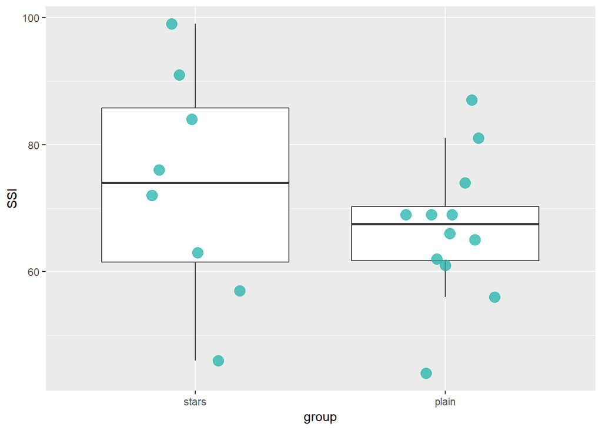

```r
sneetch_plot <- ggplot(sneetches_tidy, aes(x = group,
                                           y = SSI)) +
  geom_boxplot(outlier.shape = NA) +
  geom_jitter(position = position_jitter(height = 0, width = 0.2),
              fill = "lightseagreen",
              colour = "lightseagreen",
              alpha = 0.75,
              size = 4,
              na.rm=TRUE)
suppressWarnings(print(sneetch_plot))
```

```r
mean_diff <- sneetches_tidy %>%
  specify(SSI ~ group) %>%
  calculate(stat = "diff in means",
            order = c("stars", "plain"))
mean_diff
```

```
## # A tibble: 1 x 1
##    stat
##   <dbl>
## 1  6.58
```

```r
set.seed(2018)
sn1 <- sneetches_tidy %>%
  specify(SSI ~ group) %>%
  hypothesize(null = "independence") %>%
  generate(reps = 1, type = "permute")
sn1
```

```
## Response: SSI (numeric)
## Explanatory: group (factor)
## Null Hypothesis: independence
## # A tibble: 20 x 3
## # Groups:   replicate [1]
##      SSI group replicate
##    <dbl> <fct>     <int>
##  1    76 stars         1
##  2    81 stars         1
##  3    57 stars         1
##  4    99 stars         1
##  5    91 stars         1
##  6    72 stars         1
##  7    44 stars         1
##  8    65 stars         1
##  9    69 plain         1
## 10    69 plain         1
## 11    87 plain         1
## 12    46 plain         1
## 13    61 plain         1
## 14    69 plain         1
## 15    56 plain         1
## 16    74 plain         1
## 17    66 plain         1
## 18    62 plain         1
## 19    63 plain         1
## 20    84 plain         1
```

```r
skim_with(numeric = list(hist = NULL))

# original mean
skim(sneetches_tidy)
```

```
## Skim summary statistics
##  n obs: 20
##  n variables: 2
##
## -- Variable type:factor --------------------------------------------------------
##  variable missing complete  n n_unique             top_counts ordered
##     group       0       20 20        2 pla: 12, sta: 8, NA: 0   FALSE
##
## -- Variable type:numeric -------------------------------------------------------
##  variable missing complete  n  mean    sd p0   p25 p50   p75 p100
##       SSI       0       20 20 69.55 14.13 44 61.75  69 77.25   99
```

```r
# original means by group
sneetches_tidy %>%
  group_by(group) %>%
  skim()
```

```
## Skim summary statistics
##  n obs: 20
##  n variables: 2
##  group variables: group
##
## -- Variable type:numeric -------------------------------------------------------
##  group variable missing complete  n  mean    sd p0   p25  p50   p75 p100
##  stars      SSI       0        8  8 73.5  17.78 46 61.5  74   85.75   99
##  plain      SSI       0       12 12 66.92 11.17 44 61.75 67.5 70.25   87
```

```r
# resample mean
skim(sn1)
```

```
## Skim summary statistics
##  n obs: 20
##  n variables: 3
##  group variables: replicate
##
## -- Variable type:factor --------------------------------------------------------
##  replicate variable missing complete  n n_unique             top_counts
##          1    group       0       20 20        2 pla: 12, sta: 8, NA: 0
##  ordered
##    FALSE
##
## -- Variable type:numeric -------------------------------------------------------
##  replicate variable missing complete  n  mean    sd p0   p25 p50   p75
##          1      SSI       0       20 20 69.55 14.13 44 61.75  69 77.25
##  p100
##    99
```

```r
# resampled means by group
sn1 %>%
  group_by(group) %>%
  skim()
```

```
## Skim summary statistics
##  n obs: 20
##  n variables: 3
##  group variables: group
##
## -- Variable type:integer -------------------------------------------------------
##  group  variable missing complete  n mean sd p0 p25 p50 p75 p100     hist
##  stars replicate       0        8  8    1  0  1   1   1   1    1 ▁▁▁▇▁▁▁▁
##  plain replicate       0       12 12    1  0  1   1   1   1    1 ▁▁▁▇▁▁▁▁
##
## -- Variable type:numeric -------------------------------------------------------
##  group variable missing complete  n  mean    sd p0   p25  p50   p75 p100
##  stars      SSI       0        8  8 73.12 17.87 44 63    74   83.5    99
##  plain      SSI       0       12 12 67.17 11.24 46 61.75 67.5 70.25   87
```

```r
choose(20, 8)
```

```
## [1] 125970
```

```r
set.seed(1980)
null_distn <- sneetches_tidy %>%
  specify(SSI ~ group) %>%
  hypothesize(null = "independence") %>%
  generate(reps = 1000, type = "permute") %>%
  calculate(stat = "diff in means",
            order = c("stars", "plain"))
```

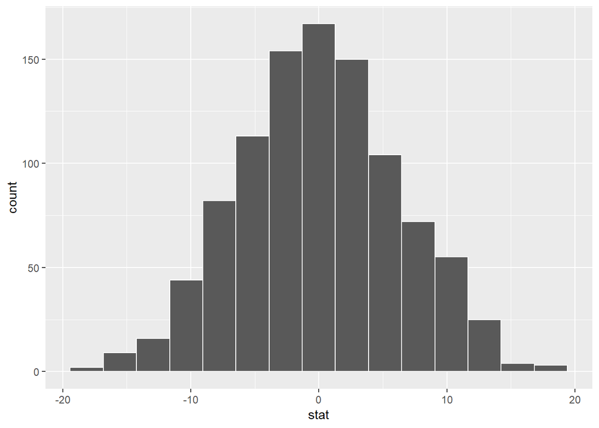

```r
null_distn %>%
  visualize()
```

```r
mean_diff_number <- mean_diff %>%
  pull(1)

(pvalue <- null_distn %>%
  get_pvalue(obs_stat = mean_diff, direction = "greater"))
```

```
## # A tibble: 1 x 1
##   p_value
##     <dbl>
## 1   0.159
```

```r
# same as...
null_distn %>%
  count(val = stat >= mean_diff_number)
```

```
## # A tibble: 2 x 2
##   val       n
##   <lgl> <int>
## 1 FALSE   841
## 2 TRUE    159
```

```r
159/(841+159)
```

```
## [1] 0.159
```

```r
boot_sneetch_ci <- sneetches_tidy %>%
  specify(SSI ~ group) %>%
  #hypothesize(null = "independence") %>%
  generate(reps = 1000, type = "bootstrap") %>%
  calculate(stat = "diff in means",
            order = c("stars", "plain")) %>%
  get_ci()

boot_sneetch_ci
```

```
## # A tibble: 1 x 2
##   `2.5%` `97.5%`
##    <dbl>   <dbl>
## 1  -7.54    20.0
```

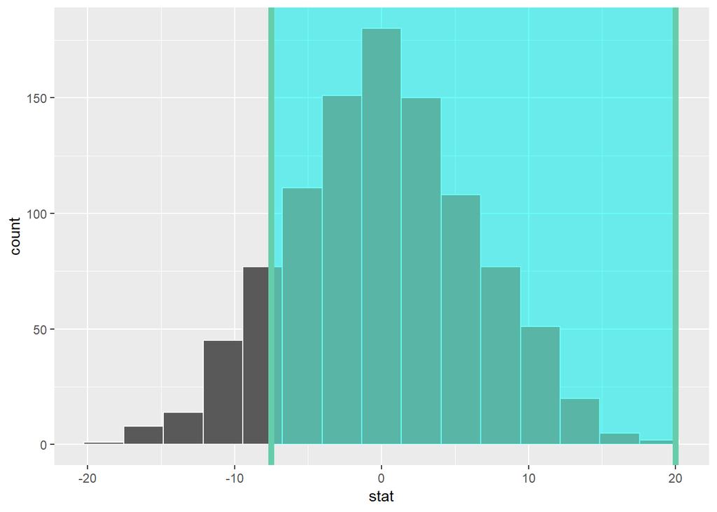

```r
#see ci
null_distn %>%
  visualize(endpoints = boot_sneetch_ci,
            direction = "between")
```

## The question to ask yourself when looking at this plot is: is 0 in my 95% confidence interval? If it is, then a difference of 0 is plausible, and I cannot reject the null hypothesis.

Zero IS within the confidence interval, so we cannot reject the null hypothesis.

## my reiteration

The general idea here is that, for a two population set of data, one measure of stat measure significance is a permutation test wherein the metric associated with each population has the labels (population identity) shuffled (while maintaining sample sizes). This is done for all (or many) of the sample permuations and creates a distribution of the data. Our population stat metrics can then be overlaid or compared to this to see where it falls in the full data distribution. If the sub-set of data that represents one population is significantly outside the expected values of the full dataset, then it can be assumed to be significantly different. Alternatively, if it is not, then the data differences may have been due to sampling randomness.